# aula-6_indo_alem_na_datavis

Baruque Rodrigues

2023-04-29

## Revendo elementos do ggplot

Construindo gráficos

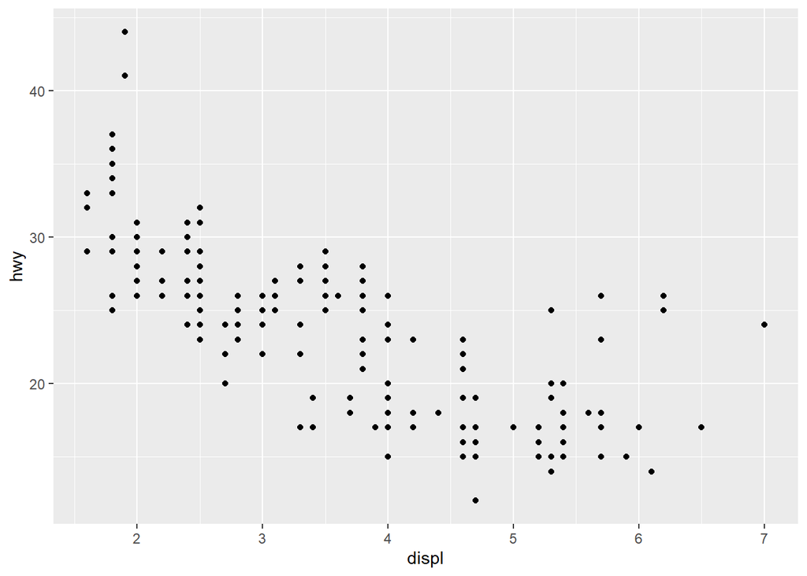

```r
ggplot(data = mpg, #Insiro o dataset
       aes(# Insiro as informações estéticas
         x = displ, # Declaro o Valor do eixo X
         y = hwy # Declaro o Valor do eixo Y
         )

)+ # O operador + indica uma nova layer
  geom_point( #Indico a geometria desejada

  )
```

## Os 5 tipos de gráficos

### Gráfico Univariados

Histogramas

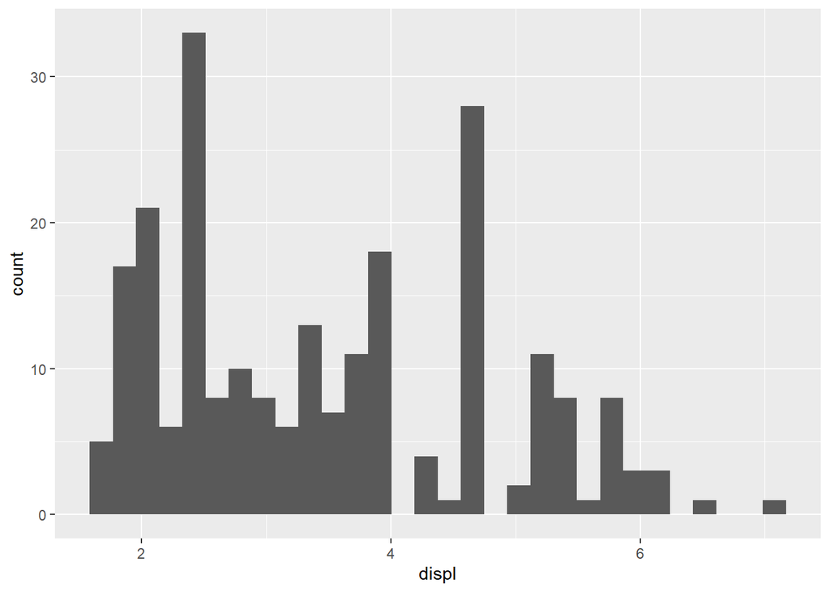

```r
mpg %>%
  ggplot(aes( x = displ))+
  geom_histogram()
```

Boxplots

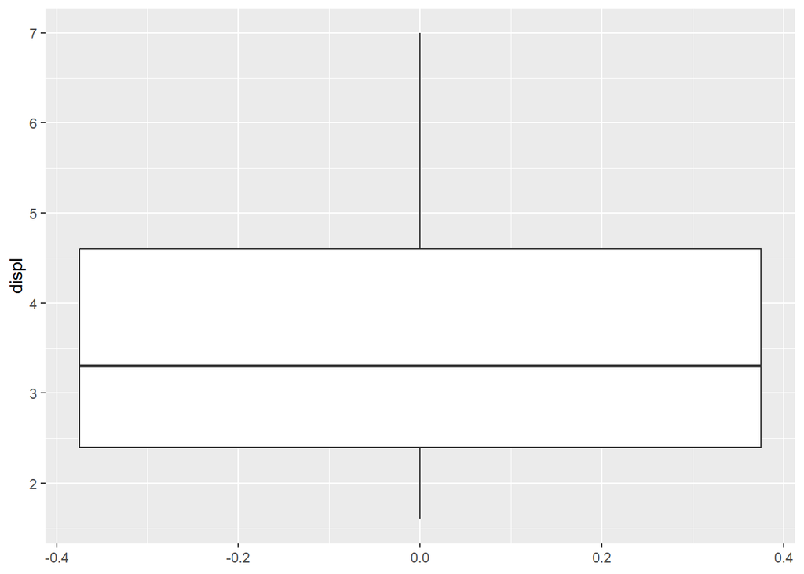

```r
mpg %>%
  ggplot(aes( y = displ))+
  geom_boxplot()
```

Gráficos de Barras

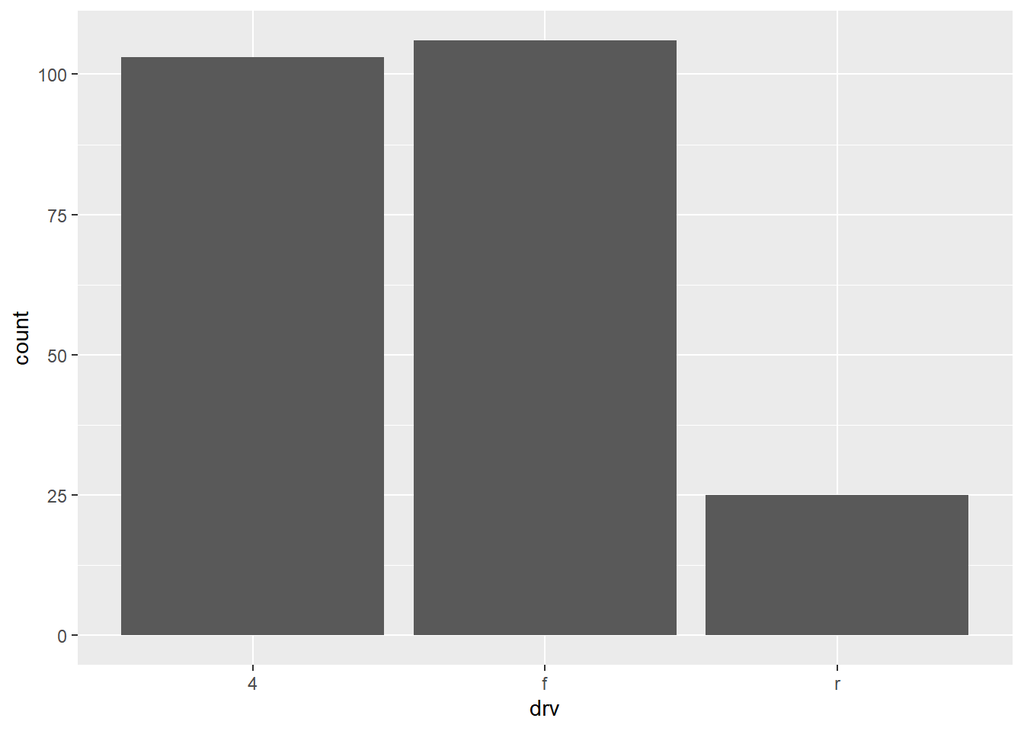

```r
mpg %>%
  ggplot(aes( x= drv))+
  geom_bar()
```

### Gráficos Bivariados

Gráficos de dispersão

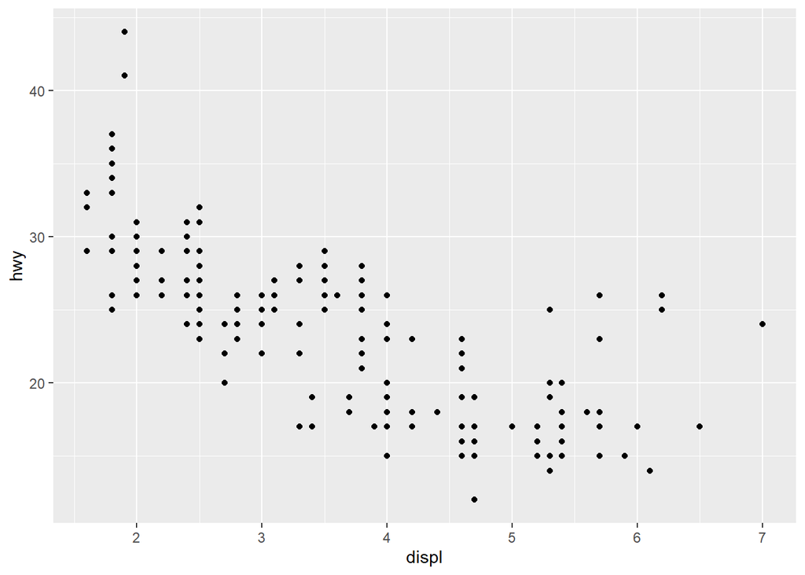

```r
mpg %>%
  ggplot(
    aes(x = displ, y = hwy)
  )+
  geom_point()
```

Gráficos de Linha

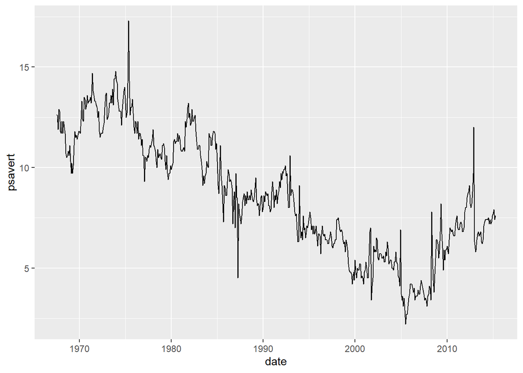

```r
economics %>%
  ggplot(
    aes(x = date,
        y = psavert))+
  geom_line()
```

### Construindo uma visualização que use os elementos apresentados na última Aula

[output not shown]

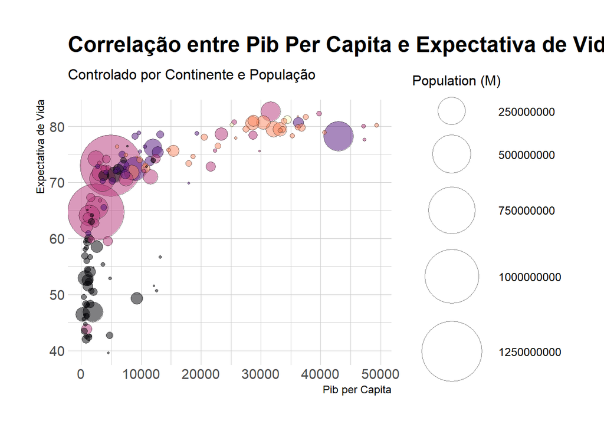

```r
#Filtrando os dados
gapminder::gapminder %>%
  filter(year == 2007) %>%
  select(-year) %>%
  #Organizando os dados
  arrange(desc(pop)) %>%
  mutate(country = factor(country, country)) %>%
  #Inciando a Visualização
  ggplot( #uso a função ggplot para iniciar uma visualização de dados
    # Mapeio as variáveis de interesse
    aes(x=gdpPercap, y=lifeExp, size=pop, fill=continent)
    ) +
  #Construo um gráfico de Dispersão
  geom_point(alpha=0.5, shape=21, color="black") +
  #Padronizo o tamanho dos pontos
  scale_size(range = c(.1, 24), name="Population (M)") +
  #Altero a Cor dos gráficos
  viridis::scale_fill_viridis(discrete=TRUE, guide=FALSE, option="A") +
  #Insiro um tema
  hrbrthemes::theme_ipsum() +
  #Faço alterações na visualização
  #theme(legend.position="bottom") +
  #Rótulos de Legenda
  labs(x= "Pib per Capita",
       y = "Expectativa de Vida",
       title = "Correlação entre Pib Per Capita e Expectativa de Vida",
       subtitle = "Controlado por Continente e População")
```

## Revisão

Construa um gráfico de dispersão no dataset mpg entre as variáveis displ e hwy, no padrão abnt com título e fonte.

Faça a mesma visualização acima, adicionando a cor pela variável class

Construa um gráfico de dispersão entre displ e hwy com um painel pela variável class com 3 colunas

Construa uma visualização com um modelo linear entre displ e hwy para cada tipo de drv

## Visualização Espacial

Executar uma visualização espacial no R é muito simples:

Para coletar informações espaciais sobre os dados brasileiros sempre utilizamos o pacote do ibge geobr. Apenas precisamos indicar o dataset que contem as informações de latitude e de longitude.

```r
 malha_rj <- geobr::read_municipality(code_muni = 33)
```

```
## Using year 2010
```

[output not shown]

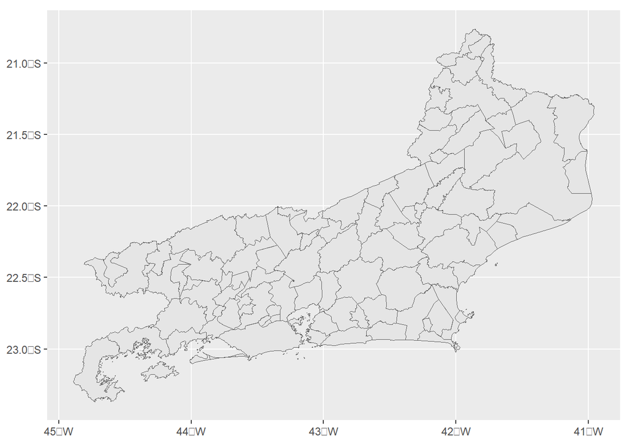

```r
 malha_rj %>% #passo os meus dados
   ggplot()+ #uso a função ggplot para iniciar uma visualização de dados
    geom_sf() #uso o geom_sf para construir uma visualização espacial
```

Pegando os dados da posição das sedes municipais

```r
 sedes_mun_rj <- geobr::read_municipal_seat()
```

```
## Using year 2010
```

[output not shown]

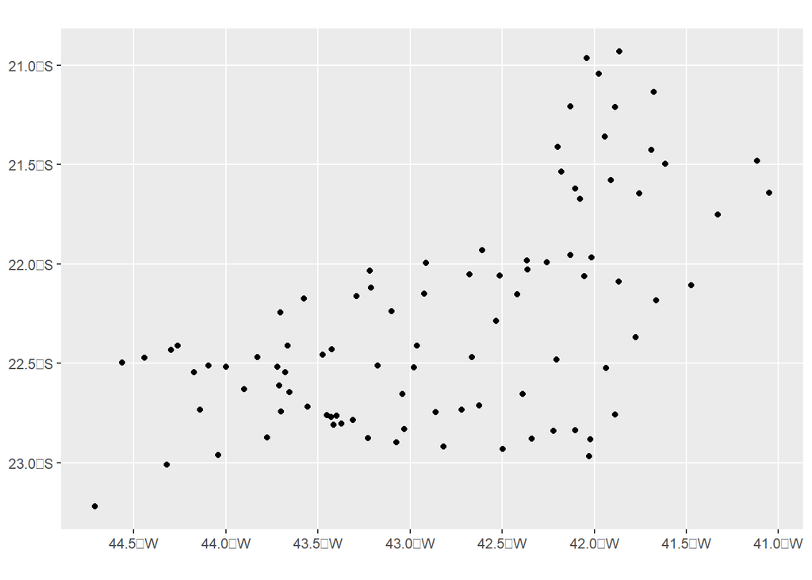

```r
 sedes_mun_rj %>%
    filter(code_state == 33) %>%
    ggplot()+
    geom_sf()
```

Printando os municipios ocm as sedes municipais

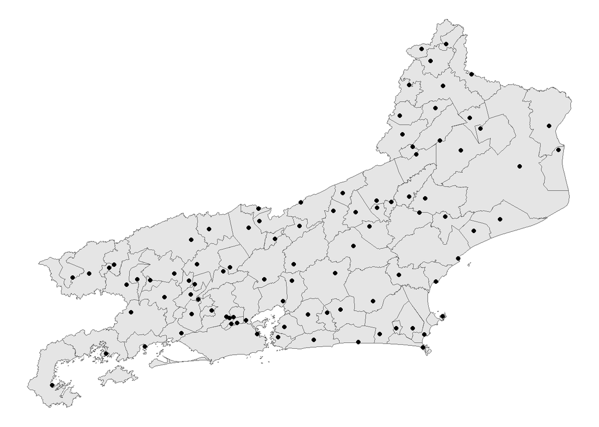

```r
  malha_rj  %>%
    ggplot()+
    geom_sf()+
    geom_sf(data = sedes_mun_rj %>%
              filter(code_state ==33))+
    theme_void()
```

Pegando as coordenadas das escolas do RJ e visualizando espacialmente

```r
 escolas <- geobr::read_schools() %>%
   filter(abbrev_state == "RJ")
```

```
## Using year 2020
```

[output not shown]

[output cut: 2952 more lines]

[output not shown]

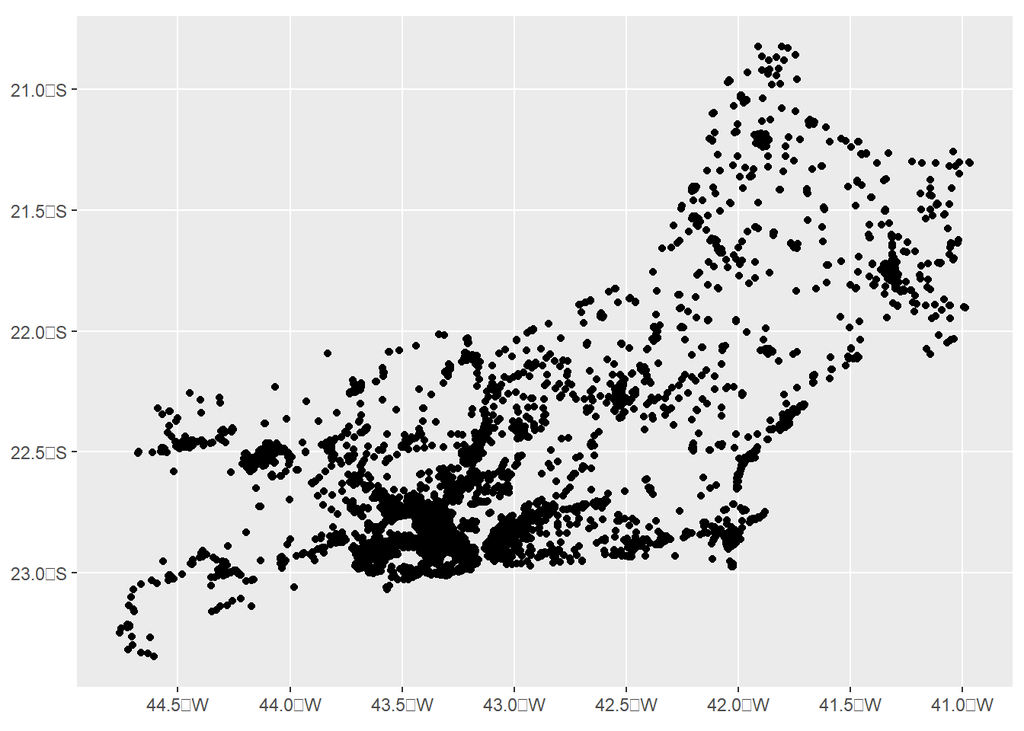

```r
 escolas %>%
   ggplot()+
   geom_sf()
```

Observando a distribuição das escolas

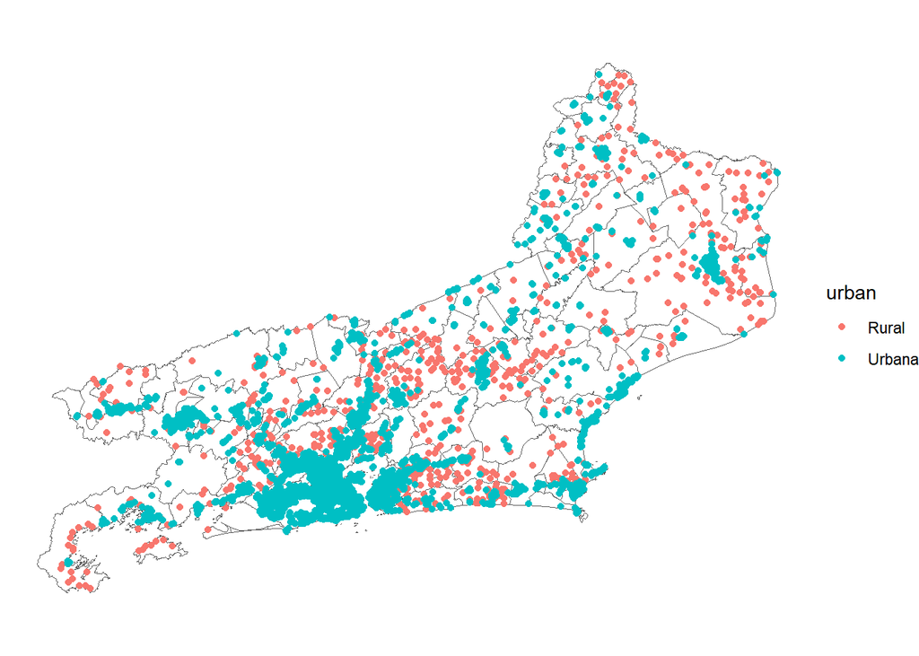

```r
malha_rj %>%
   ggplot() +
   geom_sf(fill = "white")+
   geom_sf(data = escolas,
           aes(color = urban))+
   theme_void()
```

## Comunicando Modelos e Coeficientes

Utilizaremos o Pacote {sjPlot}

Comunicando modelos para testes de x²

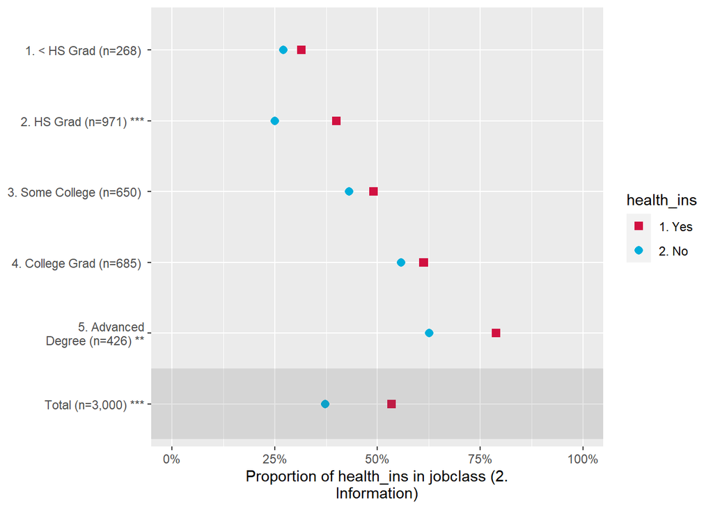

```r
library(sjPlot)
wage <- ISLR::Wage

wage %>%
  plot_gpt(x = health_ins, y = jobclass, grp = education)
```

Comunicando coeficientes de modelos de regressão

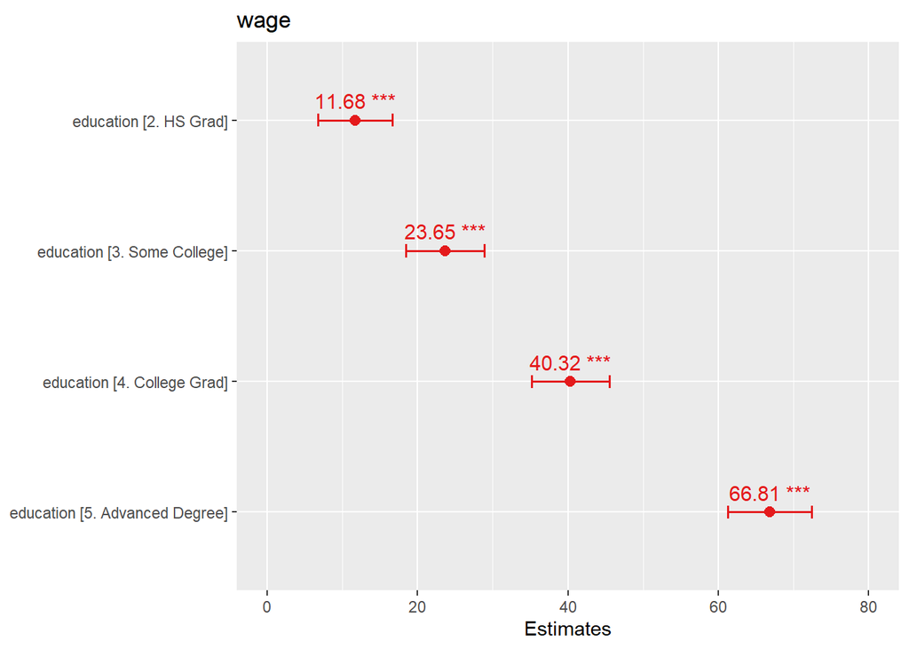

```r
modelo <- lm(wage ~ education,
             data = wage)

plot_model(modelo,
           show.values = TRUE, width = 0.1)
```

Comunicando Tabelas de Modelos

```r
tab_model(modelo,
          show.reflvl = T,
          show.intercept = F,
          p.style = "numeric_stars")
```

wage

Predictors

Estimates

CI

p

1. < HS Grad

*Reference*

2. HS Grad

11.68 ***

6.74 – 16.62

**<0.001**

3. Some College

23.65 ***

18.45 – 28.85

**<0.001**

4. College Grad

40.32 ***

35.16 – 45.48

**<0.001**

5. Advanced Degree

66.81 ***

61.23 – 72.40

**<0.001**

Observations

3000

R<sup>2</sup> / R<sup>2</sup> adjusted

0.235 / 0.234

- p<0.05 ** p<0.01 *** p<0.001